# Module2_Exercise1

Laura Huber

May 16, 2019

## Loading library

```r
require(deSolve)
```

## Set a function:

```r
sir.model.close <- function (t, x, params) {    #here we begin a function with three arguments
  S <- x[1]                               #create local variable S, the first element of x
  I <- x[2]                               #create local variable I
  R <- x[3]                               #create local variable R
  with(                                   #we can simplify code using "with"
       as.list(params),                   #this argument to "with" lets us use the variable names
       {                                  #the system of rate equations
         dS <- -beta*S*I
         dI <- beta*S*I-gamma*I
         dR <- gamma*I
         dx <- c(dS,dI,dR)                #combine results into a single vector dx
         list(dx)                         #return result as a list
       }
       )
}
```

## Setting values

### Exercise 1

If I change beta (transmission rate) to 0.8 and lambda (infectious rate) to 1/20, I obtained a graph that shows fast shift of Infectious cases over time and a rapid increase of number of people infected compared with susceptible. I.e., I might have accelarated the process of epidemics. ### Exercise 2 If I change Susceptible, instead of nearly 100%, to 50% (5000/10000), I can see that the shape is similar, but that in the scale of the Infectious over time, it only reach to half of what it was before. Same for the comparison Infectious vs Susceptible.

```r
times <- seq(0,120,by=5)                    #function seq returns a sequence
params <- c(beta=0.8,gamma=1/20)             #function c "c"ombines values into a vector --> I changed the values of beta and gamma in here
xstart <- c(S=5000/10000,I=1/10000,R=5000)     #initial conditions --> I changed to 5000/10000
```

## Saving in database

```r
out2 <- as.data.frame(ode(xstart,times,sir.model.close,params))  #result stored in dataframe --> I changed to opened for Exercise 3
```

## Plotting

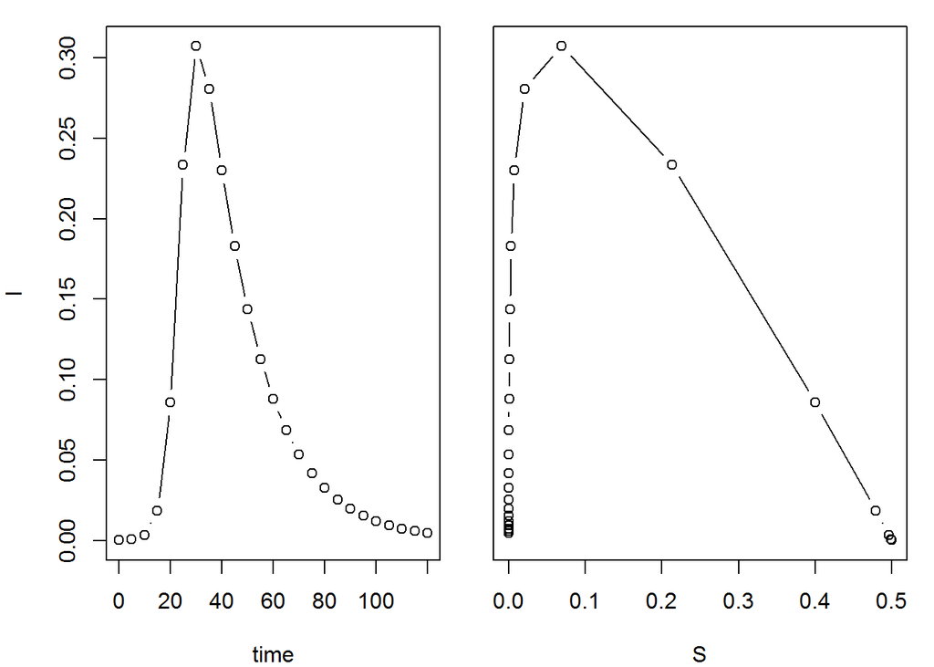

```r
op <- par(fig=c(0,0.5,0,1),mar=c(4,4,1,1))                  #set graphical parameters
plot(I~time,data=out2,type='b')                              #plot the I variable against time
par(fig=c(0.5,1,0,1),mar=c(4,1,1,1),new=T)                  #re-set graphical parameters
plot(I~S,data=out2,type='b',yaxt='n',xlab='S')               #plot phase portrait
```

```r
par(op)
```

### Exercise 3

First, I need to write a new function:

```r
sir.model.open <- function (t, x, params2) {
S <- x[1]
I <- x[2]
R <- x[3]
with(
as.list(params2),
{
dS <- mu*(S+I+R) -beta*S*I - mu*S
dI <- beta*S*I-gamma*I - mu*I
dR <- gamma*I - mu*R
dx <- c(dS,dI,dR)
list(dx)
}
)
}
```

Then, I have to set the values:

```r
times <- seq(0,120,by=5)                    #function seq returns a sequence
params2 <- c(beta=0.8,gamma=1/20, mu=1/50)             #function c "c"ombines values into a vector
xstart <- c(S=5000/10000,I=1/10000,R=5000) #initial conditions --> I changed to 5000/10000
```

Then I have to save in the database

```r
out3 <- as.data.frame(ode(xstart,times,sir.model.open,params2))  #result stored in dataframe
```

Then, I have to plot it

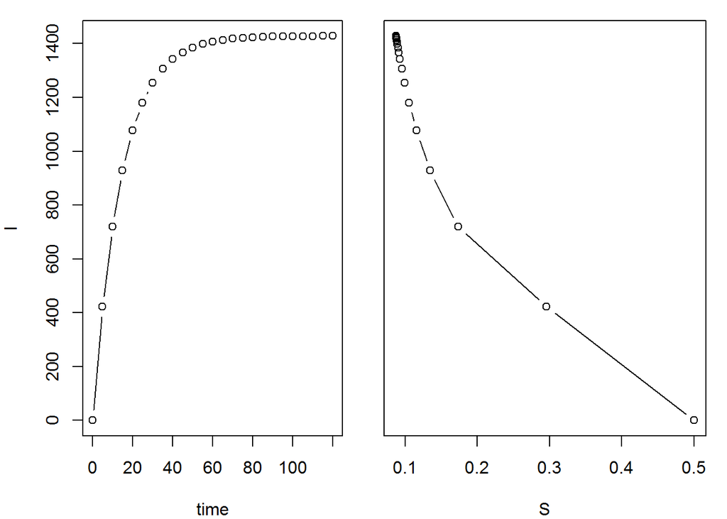

```r
op2 <- par(fig=c(0,0.5,0,1),mar=c(4,4,1,1))                  #set graphical parameters
plot(I~time,data=out3,type='b')                              #plot the I variable against time
par(fig=c(0.5,1,0,1),mar=c(4,1,1,1),new=T)                  #re-set graphical parameters
plot(I~S,data=out3,type='b',yaxt='n',xlab='S')               #plot phase portrait
```

```r
par(op2)
```

### Exercise 4

Write a new function:

```r
seir.model.closed2 <- function (t, x, params) {
S <- x[1]
E <- x[2]
I <- x[3]
R <- x[4]
with(
as.list(params),
{

dS <- -beta*S*I
dE <- beta*S*I - sigma*E
dI <- sigma*E - gamma*I
dR <- gamma*I
dx <- c(dS,dE, dI,dR)
list(dx)
}
)
}
```

Set the parameters:

```r
params3 <- c(beta=0.3,sigma=1/14, gamma=1/7)

xstart <- c(S=9999/10000, E=0, I=1/10000,R=0)
times <- seq(0,240,by=1)
```

Set dataframe

```r
out4 <- as.data.frame(ode(xstart,times,seir.model.closed2,params3))  #result stored in dataframe
```

Then, I plot

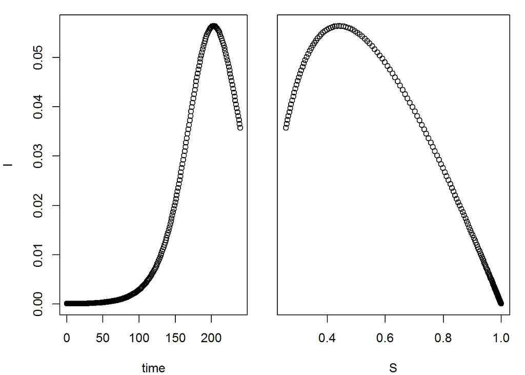

```r
op3 <- par(fig=c(0,0.5,0,1),mar=c(4,4,1,1))                  #set graphical parameters
plot(I~time,data=out4,type='b')                              #plot the I variable against time
par(fig=c(0.5,1,0,1),mar=c(4,1,1,1),new=T)                  #re-set graphical parameters
plot(I~S,data=out4,type='b',yaxt='n',xlab='S')               #plot phase portrait
```

```r
par(op3)
```

Thus, the presence of a latent period, delays the epidemics and takes longer time to reach the max value.

### In the solutions, these are the plots generated

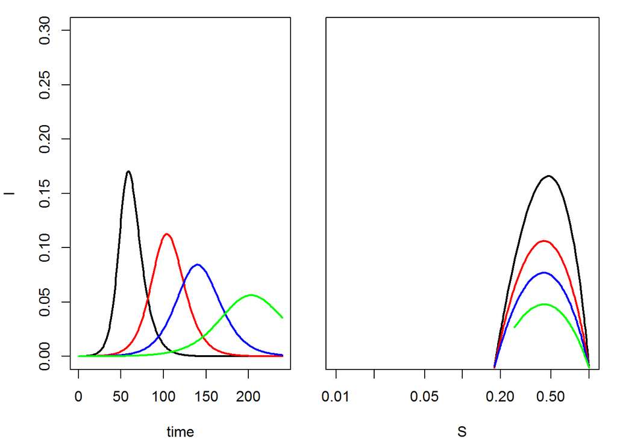

```r
params11 <- c(beta=0.3, sigma=1/0.0001, gamma=1/7)
params12 <- c(beta=0.3, sigma=1/3.5, gamma=1/7)
params13 <- c(beta=0.3, sigma=1/7, gamma=1/7)
params14 <- c(beta=0.3, sigma=1/14, gamma=1/7)

out11 <- as.data.frame(lsoda(xstart,times,seir.model.closed2,params11))
out12 <- as.data.frame(lsoda(xstart,times,seir.model.closed2,params12))
out13 <- as.data.frame(lsoda(xstart,times,seir.model.closed2,params13))
out14 <- as.data.frame(lsoda(xstart,times,seir.model.closed2,params14))
op <- par(fig=c(0,0.5,0,1),mar=c(4,4,1,1))
plot(I~time,data=out11,type='l', lwd=2, ylim=c(0, 0.3))
lines(I~time,data=out12,type='l', lwd=2, col='red')
lines(I~time,data=out13,type='l', lwd=2, col='blue')
lines(I~time,data=out14,type='l', lwd=2, col='green')

par(fig=c(0.5,1,0,1),mar=c(4,1,1,1),new=T)
plot(I~S,data=out11,type='l',lwd=2, log='x',yaxt='n',xlab='S', ylim=c(0.01, 0.3), xlim=c(0.01, 1))
lines(I~S,data=out12,type='l', lwd=2, col='red')
lines(I~S,data=out13,type='l', lwd=2, col='blue')
lines(I~S,data=out14,type='l', lwd=2, col='green')
```

```r
par(op)
```

They used many different parameters combinations to generate the plot with differnt lattent periods. As you increase latent period, you also increase the delay of epidemic takeoff.